# Normal quantile plots

## The normal quantile plot

- see that normal distributions of data (or being normal enough) important
- only tools we have to assess this are histograms and maybe boxplots
- a better tool is **normal quantile plot**:
  - plot data against what you expect if data actually normal
  - look for points to follow a straight line, at least approx
- `ggplot` code: `aes` `sample`; geoms `stat_qq` and `stat_qq_line`

## Packages

The usual:

```r
library(tidyverse)
```

## Kids learning to read

```
Rows: 44
Columns: 2
$ group <chr> "t", "t", "t", "t", "t", "t", "t", "t", "t", "t", "t", "t", "t",…
$ score <dbl> 24, 61, 59, 46, 43, 44, 52, 43, 58, 67, 62, 57, 71, 49, 54, 43, …
```

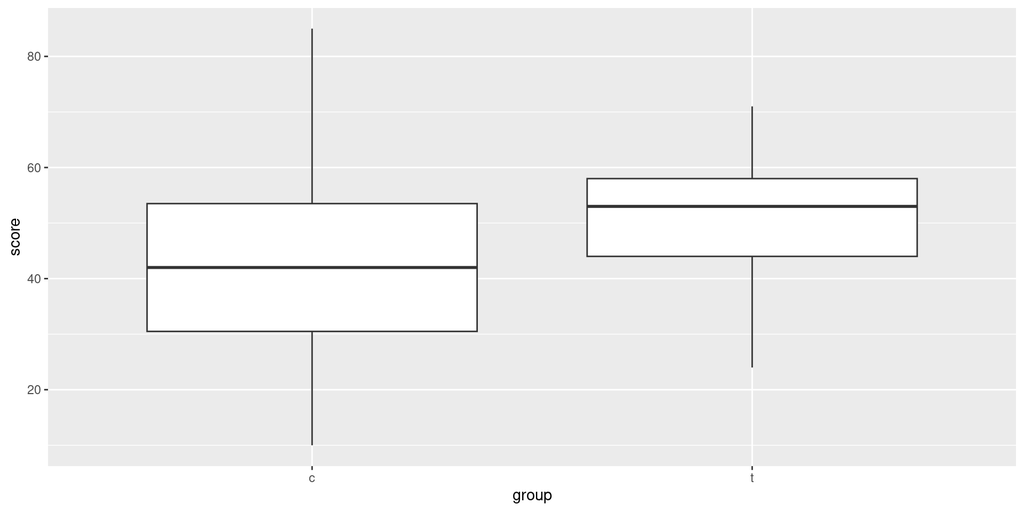

```r
ggplot(kids, aes(x = group, y = score)) + geom_boxplot()
```

Each group looks more or less normal, or at least close to symmetric.

## Get the groups separately

```r
kids %>% filter(group == "t") -> treatment
kids %>% filter(group == "c") -> control
treatment
```

| group | score |
| --- | --- |
| t | 24 |
| t | 61 |
| t | 59 |
| t | 46 |
| t | 43 |
| t | 44 |
| t | 52 |
| t | 43 |
| t | 58 |
| t | 67 |

[output cut: 11 more lines]

to check

```r
treatment %>% count(group)
```

| group | n |
| --- | --- |
| t | 21 |

```r
control %>% count(group)
```

| group | n |
| --- | --- |
| c | 23 |

## The treatment group

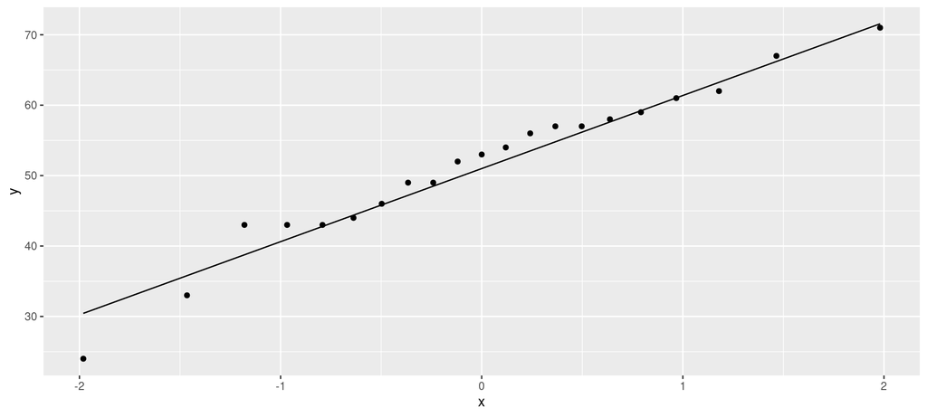

```r
ggplot(treatment, aes(sample = score)) +
  stat_qq() + stat_qq_line()
```

only problem here is lowest value a little too low (mild outlier).

## Control group

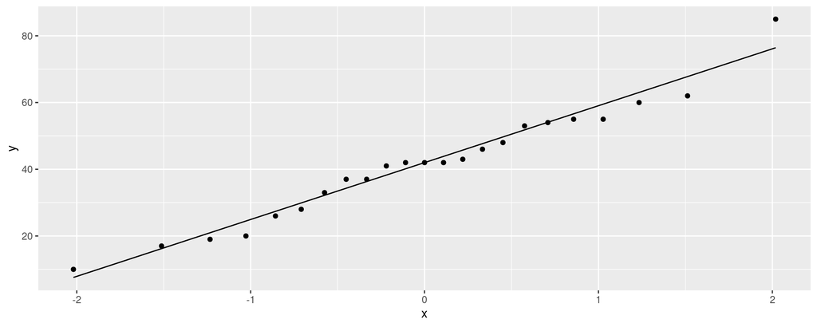

```r
ggplot(control, aes(sample = score)) +
  stat_qq() + stat_qq_line()
```

This time, highest value a little too high, but again, no real problem with normality.

## Facetting more than one sample

Use the whole data set and facet by groups

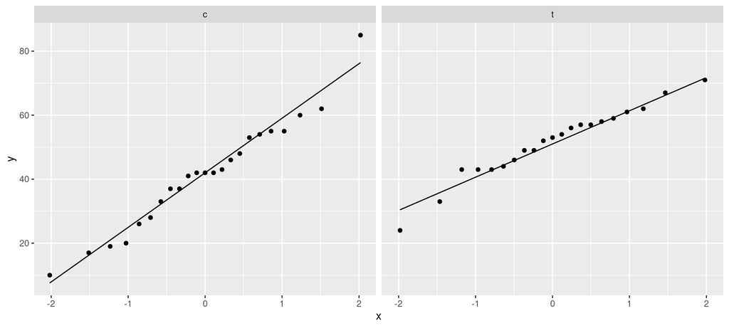

```r
ggplot(kids, aes(sample = score)) +
  stat_qq() + stat_qq_line() + facet_wrap(~group)
```

## Blue Jays attendances, skewed to right

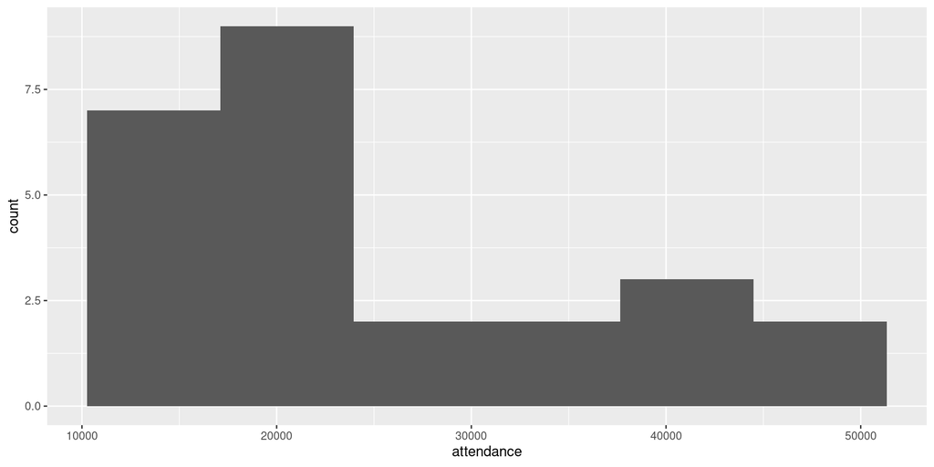

```r
ggplot(jays, aes(x = attendance)) + geom_histogram(bins = 6)
```

## On a normal quantile plot

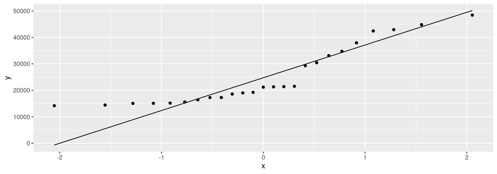

```r
ggplot(jays, aes(sample = attendance)) +
  stat_qq() + stat_qq_line()
```

- Attendances at low end too bunched up: skewed to right.
- Right-skewness can also show up as highest values being too high, or as a curved pattern in the points.

## More normal quantile plots

- How straight does a normal quantile plot have to be?
- There is randomness in real data, so even a normal quantile plot from normal data won’t look perfectly straight.
- With a small sample, can look not very straight even from normal data.
- Looking for systematic departure from a straight line; random wiggles ought not to concern us.
- Look at some examples where we know the answer, so that we can see what to expect.

## Normal data, large sample

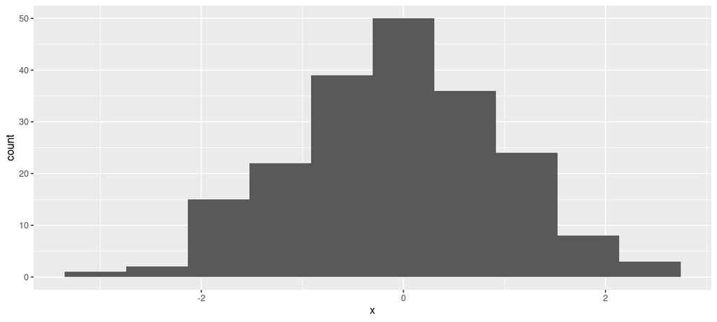

```r
d <- tibble(x=rnorm(200))
ggplot(d, aes(x=x)) + geom_histogram(bins=10)
```

## The normal quantile plot

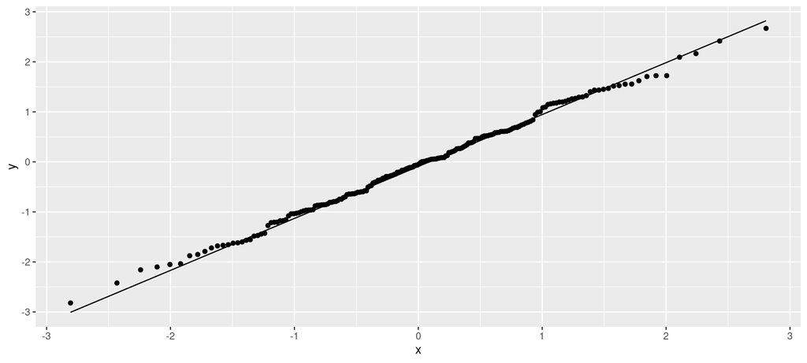

```r
ggplot(d,aes(sample=x))+stat_qq()+stat_qq_line()
```

## Normal data, small sample

- Not so convincingly normal, but not obviously skewed:

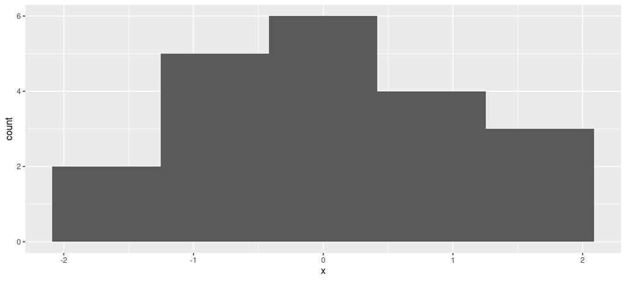

```r
d <- tibble(x=rnorm(20))
ggplot(d, aes(x=x)) + geom_histogram(bins=5)
```

## The normal quantile plot

Good, apart from the highest and lowest points being slightly off. I’d call this good:

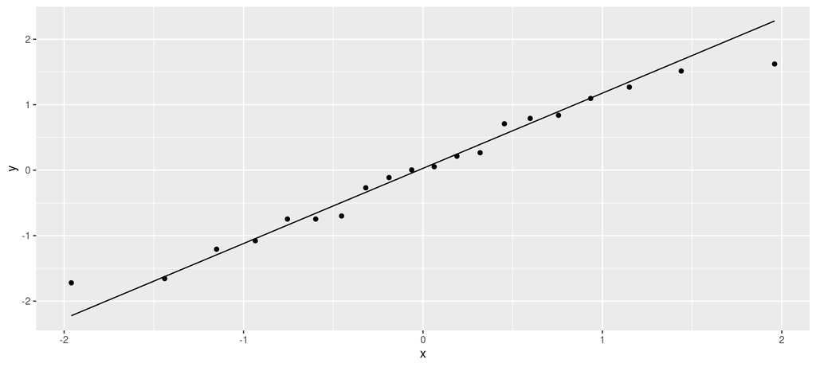

```r
ggplot(d, aes(sample=x)) + stat_qq() + stat_qq_line()
```

## Chi-squared data, *df* = 10

Somewhat skewed to right:

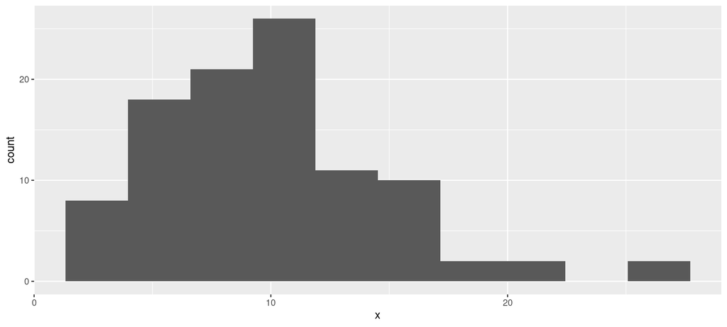

```r
d <- tibble(x=rchisq(100, 10))
ggplot(d,aes(x=x)) + geom_histogram(bins=10)
```

## The normal quantile plot

Somewhat opening-up curve:

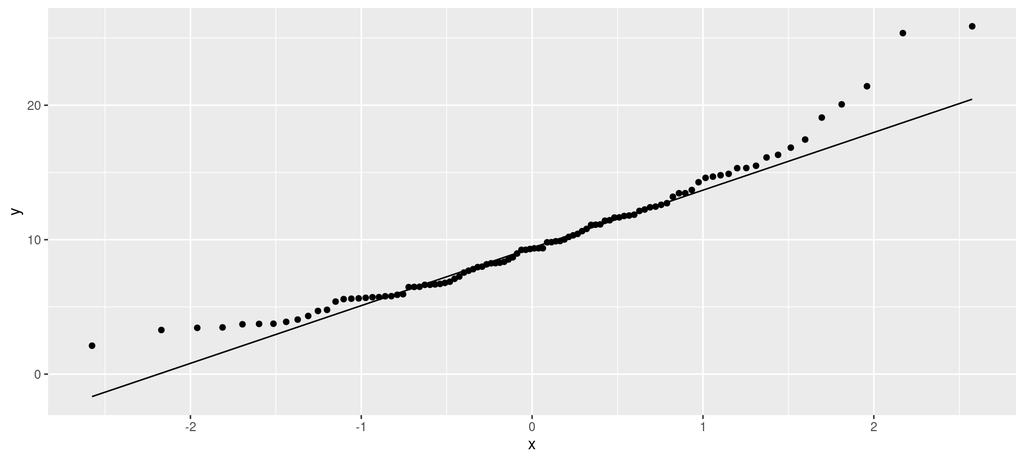

```r
ggplot(d,aes(sample=x))+stat_qq()+stat_qq_line()
```

## Chi-squared data, df = 3

Definitely skewed to right:

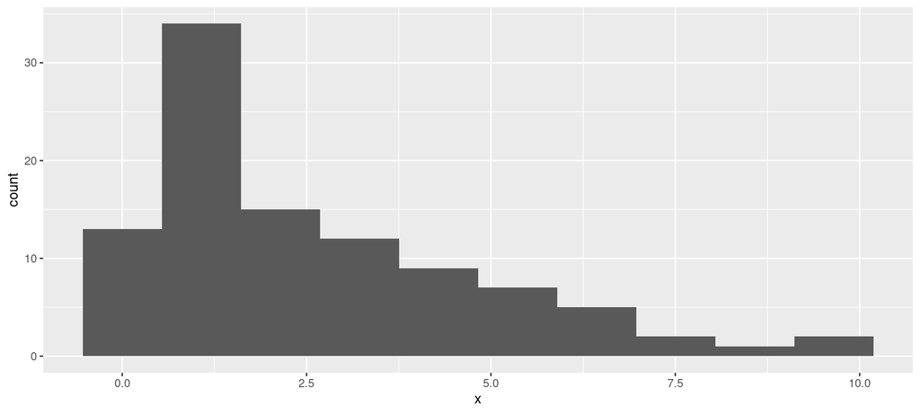

```r
d <- tibble(x=rchisq(100, 3))
ggplot(d, aes(x=x)) + geom_histogram(bins=10)
```

## The normal quantile plot

Clear upward-opening curve:

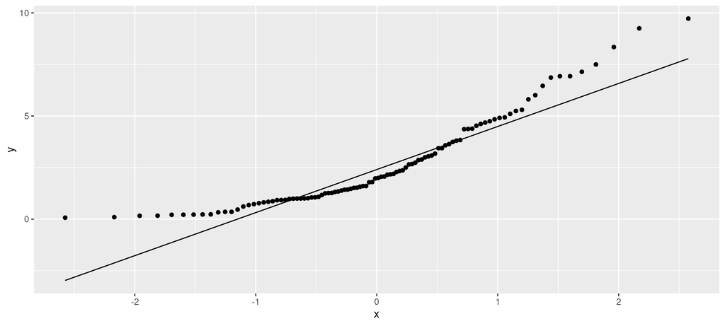

```r
ggplot(d,aes(sample=x))+stat_qq()+stat_qq_line()
```

## t-distributed data, df = 3

Long tails (or a very sharp peak):

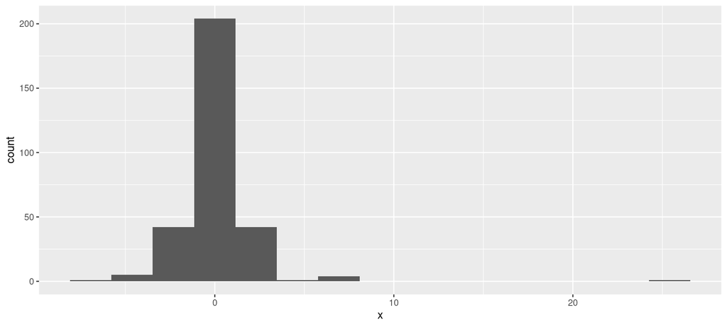

```r
d <- tibble(x=rt(300, 3))
ggplot(d, aes(x=x)) + geom_histogram(bins=15)
```

## The normal quantile plot

Low values too low and high values too high for normal.

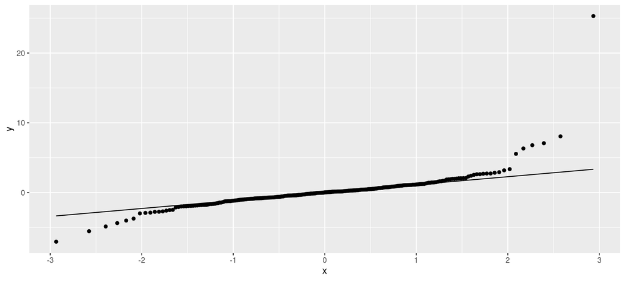

```r
ggplot(d,aes(sample=x))+stat_qq()+stat_qq_line()
```

## Summary

On a normal quantile plot:

- points following line (with some small wiggles): normal.
- kind of deviation from a straight line indicates kind of nonnormality:
  - a few highest point(s) too high and/or lowest too low: outliers
  - else see how points at each end off the line:

|  | High points |  |
| --- | --- | --- |
| **Low points** | **Too low** | **Too high** |
| **Too low** | Skewed left | Long tails |
| **Too high** | Short tails | Skewed right |

- short-tailed distribution OK for $t$ (mean still good), but others problematic (depending on sample size).